```python
import pandas as pd
import numpy as np
import matplotlib.pyplot as plt
from collections import Counter
from sklearn.pipeline import Pipeline
from imblearn.pipeline import Pipeline as ImbPipeline
from imblearn.over_sampling import SMOTE
from sklearn.preprocessing import OneHotEncoder, OrdinalEncoder
from sklearn.model_selection import train_test_split, StratifiedKFold, RandomizedSearchCV
from sklearn.impute import SimpleImputer
from sklearn.compose import ColumnTransformer
from sklearn.ensemble import RandomForestClassifier
from xgboost import XGBClassifier
from sklearn.utils.class_weight import compute_sample_weight
from sklearn.metrics import accuracy_score, recall_score, precision_score, f1_score, precision_recall_fscore_support, balanced_accuracy_score, classification_report, confusion_matrix
```

# Dataset

```python
# Ensure pandas displays every column in the dataframe
pd.set_option('display.max_columns', None)
pd.set_option('display.width', None)
```

```python
df = pd.read_csv("Credis_Score_Dataset_B.csv")
```

```python
df.head()
```

|  | ID | Customer_ID | Month | Name | Age | SSN | Occupation | Annual_Income | Monthly_Inhand_Salary | Num_Bank_Accounts | Num_Credit_Card | Interest_Rate | Num_of_Loan | Type_of_Loan | Delay_from_due_date | Num_of_Delayed_Payment | Changed_Credit_Limit | Num_Credit_Inquiries | Credit_Mix | Outstanding_Debt | Credit_Utilization_Ratio | Credit_History_Age | Payment_of_Min_Amount | Total_EMI_per_month | Amount_invested_monthly | Payment_Behaviour | Monthly_Balance | Credit_Score |
| --- | --- | --- | --- | --- | --- | --- | --- | --- | --- | --- | --- | --- | --- | --- | --- | --- | --- | --- | --- | --- | --- | --- | --- | --- | --- | --- | --- | --- |
| 0 | 0xc765 | CUS_0xade3 | April | Kevin Limx | 49 | #F%$D@*&8 | Entrepreneur | 165076.44 | NaN | 1 | 6 | 3 | -100 | Personal Loan, and Credit-Builder Loan | 11 | 2 | 3.71 | 5.0 | Good | 712.94 | 29.051769 | 18 Years and 2 Months | No | 273.174717 | 1130.5113527934434 | Low_spent_Large_value_payments | 248.55092985209012 | Standard |
| 1 | 0x1fbf9 | CUS_0x7651 | April | Slaterv | 40 | 300-72-2019 | Manager | 57321.36 | 4666.780 | 10 | 10 | 22 | 9 | Payday Loan, Payday Loan, Payday Loan, Persona... | 45 | 14 | 4.68 | 7.0 | Bad | 2224.09 | 27.436038 | NaN | Yes | 420.888678 | 68.80243048143443 | High_spent_Medium_value_payments | 226.9868910810159 | Standard |
| 2 | 0x15891 | CUS_0x84fe | April | Leee | 38 | 579-44-7984 | _______ | 30111.3 | NaN | 7 | 5 | 15 | 9 | Auto Loan, Mortgage Loan, Personal Loan, Not S... | 53 | 19 | 6.31 | 14.0 | Bad | 3075.29 | 38.259660 | 4 Years and 2 Months | Yes | 140.836626 | __10000__ | High_spent_Small_value_payments | 257.0932938020279 | Poor |
| 3 | 0x3ee7 | CUS_0x7620 | June | Fionag | 24 | #F%$D@*&8 | Developer | 36496.38_ | 2934.365 | 8 | 3 | 30 | 3 | Home Equity Loan, Credit-Builder Loan, and Aut... | 12 | 18 | 12.46 | 10.0 | Standard | 1328.69 | 36.750990 | NaN | Yes | 45.812349 | NaN | High_spent_Medium_value_payments | 390.7583756600934 | Poor |
| 4 | 0x1e5aa | CUS_0x5572 | May | Hyunjoo Jina | 39 | 972-53-4211 | Scientist | 10068.97 | NaN | 8 | 4 | 7 | 3 | Payday Loan, Credit-Builder Loan, and Debt Con... | 29 | 17 | 10.8 | 4.0 | Standard | 2192.93 | 28.617576 | 15 Years and 1 Months | NM | 23.222251 | 46.55878243363996 | Low_spent_Medium_value_payments | 294.2270494281999 | Standard |

# A. EDA

## Drop Columns

```python
df.info()
```

```
<class 'pandas.core.frame.DataFrame'>
RangeIndex: 50000 entries, 0 to 49999
Data columns (total 28 columns):
 #   Column                    Non-Null Count  Dtype
---  ------                    --------------  -----
 0   ID                        50000 non-null  object
 1   Customer_ID               50000 non-null  object
 2   Month                     50000 non-null  object
 3   Name                      45058 non-null  object
 4   Age                       50000 non-null  object
 5   SSN                       50000 non-null  object
 6   Occupation                50000 non-null  object
 7   Annual_Income             50000 non-null  object
 8   Monthly_Inhand_Salary     42512 non-null  float64
 9   Num_Bank_Accounts         50000 non-null  int64
```

[output cut: 20 more lines]

The columns : id, customer_id, name, ssn

the columns here doesnt contribute to anything in the prediction

```python
df = df.drop(columns=['ID', 'Customer_ID', 'Name', 'SSN'])
```

```python
df.head()
```

|  | Month | Age | Occupation | Annual_Income | Monthly_Inhand_Salary | Num_Bank_Accounts | Num_Credit_Card | Interest_Rate | Num_of_Loan | Type_of_Loan | Delay_from_due_date | Num_of_Delayed_Payment | Changed_Credit_Limit | Num_Credit_Inquiries | Credit_Mix | Outstanding_Debt | Credit_Utilization_Ratio | Credit_History_Age | Payment_of_Min_Amount | Total_EMI_per_month | Amount_invested_monthly | Payment_Behaviour | Monthly_Balance | Credit_Score |
| --- | --- | --- | --- | --- | --- | --- | --- | --- | --- | --- | --- | --- | --- | --- | --- | --- | --- | --- | --- | --- | --- | --- | --- | --- |
| 0 | April | 49 | Entrepreneur | 165076.44 | NaN | 1 | 6 | 3 | -100 | Personal Loan, and Credit-Builder Loan | 11 | 2 | 3.71 | 5.0 | Good | 712.94 | 29.051769 | 18 Years and 2 Months | No | 273.174717 | 1130.5113527934434 | Low_spent_Large_value_payments | 248.55092985209012 | Standard |
| 1 | April | 40 | Manager | 57321.36 | 4666.780 | 10 | 10 | 22 | 9 | Payday Loan, Payday Loan, Payday Loan, Persona... | 45 | 14 | 4.68 | 7.0 | Bad | 2224.09 | 27.436038 | NaN | Yes | 420.888678 | 68.80243048143443 | High_spent_Medium_value_payments | 226.9868910810159 | Standard |
| 2 | April | 38 | _______ | 30111.3 | NaN | 7 | 5 | 15 | 9 | Auto Loan, Mortgage Loan, Personal Loan, Not S... | 53 | 19 | 6.31 | 14.0 | Bad | 3075.29 | 38.259660 | 4 Years and 2 Months | Yes | 140.836626 | __10000__ | High_spent_Small_value_payments | 257.0932938020279 | Poor |
| 3 | June | 24 | Developer | 36496.38_ | 2934.365 | 8 | 3 | 30 | 3 | Home Equity Loan, Credit-Builder Loan, and Aut... | 12 | 18 | 12.46 | 10.0 | Standard | 1328.69 | 36.750990 | NaN | Yes | 45.812349 | NaN | High_spent_Medium_value_payments | 390.7583756600934 | Poor |
| 4 | May | 39 | Scientist | 10068.97 | NaN | 8 | 4 | 7 | 3 | Payday Loan, Credit-Builder Loan, and Debt Con... | 29 | 17 | 10.8 | 4.0 | Standard | 2192.93 | 28.617576 | 15 Years and 1 Months | NM | 23.222251 | 46.55878243363996 | Low_spent_Medium_value_payments | 294.2270494281999 | Standard |

## Datatype Mismatch

```python
df.info()
```

```
<class 'pandas.core.frame.DataFrame'>
RangeIndex: 50000 entries, 0 to 49999
Data columns (total 24 columns):
 #   Column                    Non-Null Count  Dtype
---  ------                    --------------  -----
 0   Month                     50000 non-null  object
 1   Age                       50000 non-null  object
 2   Occupation                50000 non-null  object
 3   Annual_Income             50000 non-null  object
 4   Monthly_Inhand_Salary     42512 non-null  float64
 5   Num_Bank_Accounts         50000 non-null  int64
 6   Num_Credit_Card           50000 non-null  int64
 7   Interest_Rate             50000 non-null  int64
 8   Num_of_Loan               50000 non-null  object
 9   Type_of_Loan              44324 non-null  object
```

[output cut: 16 more lines]

There is some datatype mismatch in the cols:

- age (int)
- annual_income (float)
- num_of_loan (int)
- Num_of_Delayed_Payment(int)
- Changed_Credit_Limit(float)
- Outstanding_Debt (float)
- Amount_invested_monthly (float)
- Monthly_Balance (float)

### Age

```python
numeric_age = pd.to_numeric(df['Age'], errors='coerce')
non_numeric_mask = numeric_age.isnull()
non_numeric_values = df[non_numeric_mask]['Age'].unique()
non_numeric_sorted = sorted(non_numeric_values)

print(f"Total unique non-numeric: {len(non_numeric_sorted)}")
print(f"Values: {non_numeric_sorted}")
```

```
Total unique non-numeric: 87
Values: ['1070_', '1102_', '1248_', '1447_', '14_', '1591_', '15_', '16_', '1794_', '17_', '18_', '19_', '2037_', '20_', '2111_', '2155_', '2171_', '21_', '22_', '2329_', '2373_', '23_', '2474_', '24_', '25_', '2650_', '26_', '2756_', '27_', '2812_', '2846_', '28_', '2994_', '29_', '30_', '31_', '32…
```

```python
#  Cleaning the data first so i dont remove the value which is reasonable
age_str = df['Age'].astype(str)
age_cleaned = age_str.str.replace('_', '')
numeric_age = pd.to_numeric(age_cleaned, errors='coerce')

# The reasonable age for a credit card score is between 18 and a 100
reasonable_age = (numeric_age >= 18) & (numeric_age <= 100)
df_clean = df[reasonable_age].copy()
df_clean['Age'] = numeric_age[reasonable_age]

# Check Results
print(f"Data Dropped: {(len(df) - len(df_clean))/len(df) * 100:.3f}%")
print(f"Age Type: {df_clean['Age'].dtype}")
```

```
Data Dropped: 8.414%
Age Type: int64
```

The dropped data is in a reasonable range so the data cleaning process is appropriatte and maintains the dataset integrity

### Annual_Income

```python
col = 'Annual_Income'

num_col = pd.to_numeric(df_clean[col], errors='coerce')
mask = num_col.isnull()
string_col = df_clean[mask][col].dropna().unique()
string_col_count = df_clean[mask][col].count()
print(f'Count : {string_col_count}')
string_sorted = sorted(string_col)

print(f"Total unique non-numeric: {len(string_sorted)}")
print(f"Values: {string_sorted}")
```

```
Count : 3243
Total unique non-numeric: 2860
Values: ['100058.19_', '100192.32_', '10027.07_', '10034.725_', '100358.73_', '10037.735_', '10042124.0_', '10046.24_', '100536.2_', '100555.86000000002_', '10062.445_', '100713.72_', '10079.865_', '100809.78_', '10112.045_', '101173.8_', '101203.0_', '101238.57_', '101296.71_', '101628.12_', '10164…
```

```python
col_str = df_clean[col].astype(str)
col_cleaned = col_str.str.replace('_', '')
numeric_col = pd.to_numeric(col_cleaned , errors='coerce')

df_clean[col] = numeric_col.values
print(f"Type: {df_clean[col].dtype}")
```

```
Type: float64
```

### Num_Of_Loan

```python
col = 'Num_of_Loan'

num_col = pd.to_numeric(df_clean[col], errors='coerce')
mask = num_col.isnull()
string_col = df_clean[mask][col].dropna().unique()
string_col_count = df_clean[mask][col].count()
print(f'Count : {string_col_count}')
string_sorted = sorted(string_col)

print(f"Total unique non-numeric: {len(string_sorted)}")
print(f"Values: {string_sorted}")
```

```
Count : 2201
Total unique non-numeric: 22
Values: ['0_', '1129_', '1131_', '1185_', '1219_', '1225_', '1320_', '1347_', '1_', '2_', '378_', '3_', '4_', '527_', '5_', '696_', '6_', '785_', '7_', '8_', '92_', '9_']
```

```python
col_str = df_clean[col].astype(str)
col_cleaned = col_str.str.replace('_', '')
numeric_col = pd.to_numeric(col_cleaned , errors='coerce')

df_clean[col] = numeric_col.values
print(f"Type: {df_clean[col].dtype}")
```

```
Type: int64
```

### Num_of_Delayed_Payment

```python
col = 'Num_of_Delayed_Payment'

num_col = pd.to_numeric(df_clean[col], errors='coerce')
mask = num_col.isnull()
string_col = df_clean[mask][col].dropna().unique()
string_col_count = df_clean[mask][col].count()
print(f'Count : {string_col_count}')
string_sorted = sorted(string_col)

print(f"Total unique non-numeric: {len(string_sorted)}")
print(f"Values: {string_sorted}")
```

```
Count : 1247
Total unique non-numeric: 37
Values: ['-1_', '-2_', '-3_', '0_', '10_', '11_', '1295_', '12_', '1323_', '13_', '14_', '15_', '16_', '17_', '18_', '19_', '1_', '20_', '21_', '2278_', '22_', '23_', '24_', '25_', '26_', '27_', '28_', '2_', '3840_', '3920_', '3_', '4_', '5_', '6_', '7_', '8_', '9_']
```

```python
col_str = df_clean[col].astype(str)
col_cleaned = col_str.str.replace('_', '')
numeric_col = pd.to_numeric(col_cleaned , errors='coerce')

df_clean[col] = numeric_col.values
print(f"Type: {df_clean[col].dtype}")
```

```
Type: float64
```

### Changed_Credit_Limit

```python
col = 'Changed_Credit_Limit'

num_col = pd.to_numeric(df_clean[col], errors='coerce')
mask = num_col.isnull()
string_col = df_clean[mask][col].unique()

string_col_count = df_clean[mask][col].count()
print(f'Count : {string_col_count}')

string_sorted = sorted(string_col)

print(f"Total unique non-numeric: {len(string_sorted)}")
print(f"Values: {string_sorted}")
```

```
Count : 941
Total unique non-numeric: 1
Values: ['_']
```

```python
col_str = df_clean[col].astype(str)
col_cleaned = col_str.str.replace('_', '')
numeric_col = pd.to_numeric(col_cleaned , errors='coerce')

df_clean[col] = numeric_col.values

print(f"Non-numeric/empty count: {numeric_col.isnull().sum()}")
print(f"Percentage: {numeric_col.isnull().sum() / len(numeric_col) * 100:.2f}%")
print(f"Type: {df_clean[col].dtype}")
```

```
Non-numeric/empty count: 941
Percentage: 2.05%
Type: float64
```

### Outstanding_Debt

```python
col = 'Outstanding_Debt'

num_col = pd.to_numeric(df_clean[col], errors='coerce')
mask = num_col.isnull()
string_col = df_clean[mask][col].unique()

string_col_count = df_clean[mask][col].count()
print(f'Count : {string_col_count}')
string_sorted = sorted(string_col)

print(f"Total unique non-numeric: {len(string_sorted)}")
print(f"Values: {string_sorted}")
```

```
Count : 469
Total unique non-numeric: 458
Values: ['1025.3_', '1032.13_', '1036.4_', '1043.22_', '1045.77_', '1046.3_', '1048.02_', '105.89_', '1054.86_', '1055.36_', '1056.32_', '106.28_', '1061.06_', '1064.61_', '1071.33_', '1073.76_', '1075.37_', '1076.67_', '1077.91_', '1078.64_', '1078.95_', '1080.98_', '1082.86_', '1090.21_', '1095.9_…
```

```python
col_str = df_clean[col].astype(str)
col_cleaned = col_str.str.replace('_', '')
numeric_col = pd.to_numeric(col_cleaned , errors='coerce')
df_clean[col] = numeric_col.values

print(f"Type: {df_clean[col].dtype}")
```

```
Type: float64
```

### Amount_invested_monthly

```python
col = 'Amount_invested_monthly'

num_col = pd.to_numeric(df_clean[col], errors='coerce')
mask = num_col.isnull()
string_col = df_clean[mask][col].dropna().unique()

string_col_count = df_clean[mask][col].count()
print(f'Count : {string_col_count}')
string_sorted = sorted(string_col)

print(f"Total unique non-numeric: {len(string_sorted)}")
print(f"Values: {string_sorted}")
```

```
Count : 1949
Total unique non-numeric: 1
Values: ['__10000__']
```

```python
col_str = df_clean[col].astype(str)
col_cleaned = col_str.str.replace('_', '')
numeric_col = pd.to_numeric(col_cleaned , errors='coerce')
df_clean[col] = numeric_col.values

print(f"Type: {df_clean[col].dtype}")
```

```
Type: float64
```

### Monthly_Balance

```python
col = 'Monthly_Balance'

num_col = pd.to_numeric(df_clean[col], errors='coerce')
mask = num_col.isnull()
string_col = df_clean[mask][col].dropna().unique()

string_col_count = df_clean[mask][col].count()
print(f'Count : {string_col_count}')
string_sorted = sorted(string_col)

print(f"Total unique non-numeric: {len(string_sorted)}")
print(f"Values: {string_sorted}")
```

```
Count : 3
Total unique non-numeric: 1
Values: ['__-333333333333333333333333333__']
```

```python
col_str = df_clean[col].astype(str)
col_cleaned = col_str.str.replace('_', '')
numeric_col = pd.to_numeric(col_cleaned , errors='coerce')
df_clean[col] = numeric_col.values

print(f"Type: {df_clean[col].dtype}")
```

```
Type: float64
```

### Conclusion

```python
df_clean.info()
```

```
<class 'pandas.core.frame.DataFrame'>
Index: 45793 entries, 0 to 49999
Data columns (total 24 columns):
 #   Column                    Non-Null Count  Dtype
---  ------                    --------------  -----
 0   Month                     45793 non-null  object
 1   Age                       45793 non-null  int64
 2   Occupation                45793 non-null  object
 3   Annual_Income             45793 non-null  float64
 4   Monthly_Inhand_Salary     38950 non-null  float64
 5   Num_Bank_Accounts         45793 non-null  int64
 6   Num_Credit_Card           45793 non-null  int64
 7   Interest_Rate             45793 non-null  int64
 8   Num_of_Loan               45793 non-null  int64
 9   Type_of_Loan              40356 non-null  object
```

[output cut: 16 more lines]

All the columns is in the right datatype

## Mapping the target variable

```python
df_clean['Credit_Score'].unique()
```

```
array(['Standard', 'Poor', 'Good'], dtype=object)
```

The target has to be mapped ordinally

Good > Standard > Poor

2 > 1 > 0

```python
df_clean['Credit_Score'] = df_clean['Credit_Score'].map({
    'Good' : 2,
    'Standard' : 1,
    'Poor' : 0
})
```

## Check Duplicated

```python
df.duplicated().sum()
```

```
0
```

There is no duplicated value

## Check null value

```python
nan_info = pd.DataFrame({
    'Column': df_clean.columns,
    'Count': df_clean.isnull().sum(),
    'Percentage': (df_clean.isnull().sum() / len(df_clean) * 100).round(2)
}).sort_values('Percentage', ascending=False).reset_index(drop=True)

print(nan_info[nan_info['Count'] > 0])
```

```
                    Column  Count  Percentage
0    Monthly_Inhand_Salary   6843       14.94
1             Type_of_Loan   5437       11.87
2       Credit_History_Age   4089        8.93
3   Num_of_Delayed_Payment   3319        7.25
4  Amount_invested_monthly   2023        4.42
5     Changed_Credit_Limit    941        2.05
6     Num_Credit_Inquiries    925        2.02
7          Monthly_Balance    548        1.20
```

monthly_inhand_salary shows the most missing value / nan which i will impute later in the pipeline with the median value, meanwhile the categorical with the mode value

## Cat cols

```python
cat_col = df_clean.select_dtypes(include='object')
```

```python
cat_col.columns
```

```
Index(['Month', 'Occupation', 'Type_of_Loan', 'Credit_Mix',
       'Credit_History_Age', 'Payment_of_Min_Amount', 'Payment_Behaviour'],
      dtype='object')
```

```python
for i in cat_col.columns:
    print(cat_col[i].value_counts())
    print("\n"*1)
```

```
Month
June        5748
January     5747
July        5746
August      5745
March       5740
May         5703
April       5694
February    5670
Name: count, dtype: int64


Occupation
_______          3182
Lawyer           3049
Engineer         2947
Developer        2919
Media_Manager    2892
Accountant       2870
Architect        2848
Entrepreneur     2843
Mechanic         2829
Teacher          2828
Scientist        2816
Journalist       2808
Doctor           2786
Musician         2732
Writer           2727
Manager          2717
Name: count, dtype: int64


Type_of_Loan
Not Specified                                                                                                                                               704
Credit-Builder Loan                                                                                                                                         642
Personal Loan                                                                                                                                               629
Debt Consolidation Loan                                                                                                                                     608
Student Loan                                                                                                                                                602
                                                                                                                                                           ...
Credit-Builder Loan, Auto Loan, Student Loan, Student Loan, Personal Loan, Personal Loan, and Auto Loan                                                       1
```

[output cut: 31 more lines]

```
Yes    22873
No     17445
NM      5475
Name: count, dtype: int64


Payment_Behaviour
Low_spent_Small_value_payments      11530
High_spent_Medium_value_payments     8101
Low_spent_Medium_value_payments      6351
High_spent_Large_value_payments      6306
High_spent_Small_value_payments      5143
Low_spent_Large_value_payments       4839
!@9#%8                               3523
Name: count, dtype: int64
```

There is some problem :

- Occupation : Contains '_______' with 3,182 occurrences (highest count)
- Type of loan : Contains 5,747 unique values due to combined loan types. These multi-value entries should be standardized
- Credit_Mix : Contains '_' (underscore) value with 9,256 occurrences (20%). Too high to drop so i will impute with mode
- Payment_of_Min_Amount : Contains 'NM' (Not Mentioned) with 5,475 occurrences (12%)
- Payment_Behaviour : Contains '!@9#%8' (invalid/corrupted data) with 3,523 occurrences
- Credit_History_Age : Stored as text format ("19 Years and 4 Months") instead of numeric (in month)

### Occupation

```python
df_clean['Occupation'] = df_clean['Occupation'].replace('_______', np.nan)
print((df_clean['Occupation'].isna()).sum())
```

```
3182
```

NaN values serve as placeholders for the imputer to handle during the preprocessing pipeline.

### Type_of_Loan

```python
df_clean['Type_of_Loan'].value_counts()
```

```
Type_of_Loan
Not Specified                                                                                                                                               704
Credit-Builder Loan                                                                                                                                         642
Personal Loan                                                                                                                                               629
Debt Consolidation Loan                                                                                                                                     608
Student Loan                                                                                                                                                602
                                                                                                                                                           ...
Credit-Builder Loan, Auto Loan, Student Loan, Student Loan, Personal Loan, Personal Loan, and Auto Loan                                                       1
Personal Loan, Personal Loan, Not Specified, Home Equity Loan, and Payday Loan                                                                                1
Auto Loan, Not Specified, Home Equity Loan, Credit-Builder Loan, Credit-Builder Loan, Debt Consolidation Loan, Payday Loan, Auto Loan, and Personal Loan      1
Auto Loan, Not Specified, Not Specified, and Mortgage Loan                                                                                                    1
Personal Loan, Credit-Builder Loan, Debt Consolidation Loan, Payday Loan, and Student Loan                                                                    1
Name: count, Length: 5747, dtype: int64
```

The problem is the loan column contains multivalue entries separated by commas or 'and', so to handle this, i used separate frequency columns for each valid loan type where each occurrence increments the count per row, and finally drop the original column once all frequencies are counted.

The reason i chose this was because it captures loan combination instead of ohe (just precense) and it preserves the count information and freq directly correlates with credit risk(more loan = higher risk)

```python
valid_loans = ["Student Loan", "Personal Loan", "Credit-Builder Loan",
                "Mortgage Loan", "Debt Consolidation Loan", "Payday Loan",
                "Auto Loan", "Home Equity Loan"]

loan_column = 'Type_of_Loan'
# frequency columns
for loan in valid_loans:
    df[f"{loan.replace(' ', '_').lower()}_freq"] = 0

# Populate frequencies
def count_loans(loan_string):
    if pd.isna(loan_string) or loan_string.strip() == '':
        return Counter()

    # Clean separators
    loan_string = loan_string.replace(' and ', ',')
    loans = [item.strip() for item in loan_string.split(',')]

    # Count valid loans
    return Counter([l for l in loans if l in valid_loans])

# Apply to each row
for idx, row in df_clean.iterrows():
    loan_counts = count_loans(row[loan_column])
    for loan, count in loan_counts.items():
        col_name = f"{loan.replace(' ', '_').lower()}_freq"
        df_clean.at[idx, col_name] = count

# Drop original column
df_clean.drop(columns=[loan_column], inplace=True)
```

```python
freq_columns = [col for col in df.columns if col.endswith('_freq')]

# Set nan to 0
df_clean[freq_columns] = df_clean[freq_columns].fillna(0)

# Cast to integer
df_clean[freq_columns] = df_clean[freq_columns].astype(int)
df_clean[[col for col in df if '_freq' in col]]
```

|  | student_loan_freq | personal_loan_freq | credit-builder_loan_freq | mortgage_loan_freq | debt_consolidation_loan_freq | payday_loan_freq | auto_loan_freq | home_equity_loan_freq |
| --- | --- | --- | --- | --- | --- | --- | --- | --- |
| 0 | 0 | 1 | 1 | 0 | 0 | 0 | 0 | 0 |
| 1 | 1 | 2 | 0 | 2 | 0 | 3 | 0 | 0 |
| 2 | 1 | 1 | 0 | 4 | 0 | 0 | 1 | 0 |
| 3 | 0 | 0 | 1 | 0 | 0 | 0 | 1 | 1 |
| 4 | 0 | 0 | 1 | 0 | 1 | 1 | 0 | 0 |
| ... | ... | ... | ... | ... | ... | ... | ... | ... |
| 49994 | 1 | 0 | 0 | 2 | 4 | 1 | 0 | 1 |
| 49995 | 0 | 0 | 1 | 0 | 1 | 1 | 1 | 0 |
| 49996 | 0 | 0 | 0 | 0 | 0 | 0 | 0 | 0 |
| 49997 | 1 | 1 | 0 | 1 | 0 | 0 | 0 | 0 |
| 49999 | 0 | 1 | 1 | 1 | 0 | 0 | 0 | 0 |

45793 rows × 8 columns

### Credit_Mix

```python
df_clean[df_clean['Credit_Mix'] == '_'].head(10)
```

|  | Month | Age | Occupation | Annual_Income | Monthly_Inhand_Salary | Num_Bank_Accounts | Num_Credit_Card | Interest_Rate | Num_of_Loan | Delay_from_due_date | Num_of_Delayed_Payment | Changed_Credit_Limit | Num_Credit_Inquiries | Credit_Mix | Outstanding_Debt | Credit_Utilization_Ratio | Credit_History_Age | Payment_of_Min_Amount | Total_EMI_per_month | Amount_invested_monthly | Payment_Behaviour | Monthly_Balance | Credit_Score | personal_loan_freq | credit-builder_loan_freq | payday_loan_freq | student_loan_freq | mortgage_loan_freq | auto_loan_freq | … |
| --- | --- | --- | --- | --- | --- | --- | --- | --- | --- | --- | --- | --- | --- | --- | --- | --- | --- | --- | --- | --- | --- | --- | --- | --- | --- | --- | --- | --- | --- | --- |
| 14 | August | 37 | Mechanic | 89122.380 | NaN | 3 | 4 | 14 | 5 | 6 | 7.0 | 19.64 | 8.0 | _ | 281.84 | 39.812125 | 8 Years and 9 Months | Yes | 266.083827 | 295.151154 | High_spent_Small_value_payments | 422.951519 | 0 | 0 | 2 | 1 | 0 | 0 | 1 | … |
| 25 | June | 28 | NaN | 19852.320 | 1413.360000 | 7 | 8 | 29 | 6 | 40 | 15.0 | -4.02 | 8.0 | _ | 2625.27 | 28.880071 | 16 Years and 2 Months | Yes | 52.930743 | 131.893720 | Low_spent_Small_value_payments | 246.511537 | 0 | 2 | 1 | 1 | 0 | 0 | 1 | … |
| 29 | June | 40 | Developer | 33405.740 | 2485.811667 | 3 | 6 | 20 | 1 | 28 | 8.0 | 7.77 | 0.0 | _ | 196.30 | 38.728687 | 24 Years and 2 Months | Yes | 16.280688 | 87.410199 | Low_spent_Medium_value_payments | 424.890279 | 1 | 0 | 0 | 0 | 0 | 0 | 0 | … |
| 33 | August | 36 | Writer | 21699.130 | 1925.260833 | 8 | 4 | 18 | 3 | 9 | 14.0 | 8.64 | 3.0 | _ | 1129.46 | 37.609059 | 21 Years and 3 Months | Yes | 45.060011 | 91.675268 | Low_spent_Small_value_payments | 345.790804 | 1 | 0 | 0 | 0 | 2 | 0 | 0 | … |
| 34 | May | 22 | Scientist | 21677.905 | 1859.492083 | 1 | 4 | 11 | 1 | 10 | 2.0 | 0.71 | 5.0 | _ | 585.36 | 40.910394 | 33 Years and 1 Months | No | 11.503369 | NaN | High_spent_Medium_value_payments | 357.711318 | 1 | 0 | 0 | 1 | 0 | 0 | 0 | … |
| 41 | June | 41 | Architect | 111112.760 | NaN | 7 | 5 | 13 | 0 | 29 | 18.0 | 19.75 | 6.0 | _ | 261.78 | 40.614078 | NaN | Yes | 0.000000 | 350.268758 | Low_spent_Small_value_payments | 837.370909 | 1 | 0 | 0 | 0 | 0 | 0 | 0 | … |
| 59 | July | 21 | Architect | 9901.355 | 887.973380 | 7 | 5 | 21 | -100 | 12 | 20.0 | 10.54 | 11.0 | _ | 2039.68 | 31.296697 | 10 Years and 7 Months | Yes | 51.743826 | 79.080438 | Low_spent_Small_value_payments | 282.226565 | 0 | 1 | 0 | 0 | 0 | 1 | 0 | … |
| 60 | August | 41 | Media_Manager | 17725.570 | 1691.130833 | 5 | 9 | 20 | 6 | 12 | 14.0 | 22.71 | NaN | _ | 2074.18 | 32.980188 | 8 Years and 2 Months | Yes | 83.578420 | 226.994472 | Low_spent_Small_value_payments | 148.540191 | 0 | 0 | 0 | 2 | 0 | 0 | 0 | … |
| 63 | July | 54 | Engineer | 33132.940 | 2478.078333 | 6 | 6 | 3085 | 3 | 23 | 12.0 | 0.61 | 2.0 | _ | 795.69 | 34.714806 | 21 Years and 4 Months | NM | 81.780936 | 10000.000000 | Low_spent_Medium_value_payments | 217.721057 | 1 | 0 | 2 | 0 | 0 | 1 | 0 | … |
| 64 | January | 26 | Entrepreneur | 9582.025 | 1022.502083 | 5 | 7 | 7 | 2 | 8 | 15.0 | 6.49 | 1.0 | _ | 820.12 | 23.126713 | 32 Years and 9 Months | No | 8.129069 | 48.676386 | Low_spent_Small_value_payments | 335.444754 | 0 | 1 | 0 | 1 | 0 | 0 | 0 | … |

```python
df_clean['Credit_Mix'] = df_clean['Credit_Mix'].replace('_', np.nan)
# the _ value will be made into nan which will be imputed later
```

```python
df_clean['Credit_Mix'].isna().sum()
```

```
9256
```

### Payment_of_Min_Amount

```python
df_clean['Payment_of_Min_Amount'].value_counts()
```

```
Payment_of_Min_Amount
Yes    22873
No     17445
NM      5475
Name: count, dtype: int64
```

i will assume that NM is Not Mentioned which will be treated as a missing value and therefore will be made into na and imputed later

```python
df_clean['Payment_of_Min_Amount'] = df_clean['Payment_of_Min_Amount'].replace("NM", np.nan)
```

```python
df_clean['Payment_of_Min_Amount'].isna().sum()
```

```
5475
```

### Payment_Behaviour

```python
df['Payment_Behaviour'].value_counts()
```

```
Payment_Behaviour
Low_spent_Small_value_payments      12737
High_spent_Medium_value_payments     8839
Low_spent_Medium_value_payments      6921
High_spent_Large_value_payments      6791
High_spent_Small_value_payments      5602
Low_spent_Large_value_payments       5253
!@9#%8                               3857
Name: count, dtype: int64
```

```python
df_clean['Payment_Behaviour'] = df_clean['Payment_Behaviour'].replace('!@9#%8', np.nan)
```

```python
print(df_clean['Payment_Behaviour'].value_counts())
print(df_clean['Payment_Behaviour'].isna().sum())
```

```
Payment_Behaviour
Low_spent_Small_value_payments      11530
High_spent_Medium_value_payments     8101
Low_spent_Medium_value_payments      6351
High_spent_Large_value_payments      6306
High_spent_Small_value_payments      5143
Low_spent_Large_value_payments       4839
Name: count, dtype: int64
3523
```

### Credit_History_Age

```python
df['Credit_History_Age'].value_counts()
```

```
Credit_History_Age
15 Years and 10 Months    231
19 Years and 3 Months     228
19 Years and 4 Months     227
15 Years and 8 Months     226
18 Years and 4 Months     225
                         ...
0 Years and 4 Months       14
0 Years and 3 Months       11
33 Years and 7 Months      10
33 Years and 8 Months       9
0 Years and 2 Months        6
Name: count, Length: 403, dtype: int64
```

```python
def month_converter(x):
    if pd.isna(x):
        return np.nan
    parts = x.split()
    tes = (pd.to_numeric(parts[0], errors='coerce') * 12 + pd.to_numeric(parts[3], errors='coerce'))
    return tes
```

```python
df_clean['Credit_History_Age'] = df_clean['Credit_History_Age'].apply(month_converter).astype('float64')
df_clean['Credit_History_Age'].head(10)
```

```
0    218.0
1      NaN
2     50.0
3      NaN
4    181.0
5    374.0
6    189.0
7    183.0
8    216.0
9      NaN
Name: Credit_History_Age, dtype: float64
```

```python
df['Credit_History_Age'].dtype
```

```
dtype('O')
```

## Num Cols

```python
num_col = df_clean.select_dtypes(include=['number'])
num_col.columns
```

```
Index(['Age', 'Annual_Income', 'Monthly_Inhand_Salary', 'Num_Bank_Accounts',
       'Num_Credit_Card', 'Interest_Rate', 'Num_of_Loan',
       'Delay_from_due_date', 'Num_of_Delayed_Payment', 'Changed_Credit_Limit',
       'Num_Credit_Inquiries', 'Outstanding_Debt', 'Credit_Utilization_Ratio',
       'Credit_History_Age', 'Total_EMI_per_month', 'Amount_invested_monthly',
       'Monthly_Balance', 'Credit_Score', 'personal_loan_freq',
       'credit-builder_loan_freq', 'payday_loan_freq', 'student_loan_freq',
       'mortgage_loan_freq', 'auto_loan_freq', 'home_equity_loan_freq',
       'debt_consolidation_loan_freq'],
      dtype='object')
```

```python
num_col.drop(columns='Credit_Score', inplace=True)
```

```python
num_col.describe()
```

|  | Age | Annual_Income | Monthly_Inhand_Salary | Num_Bank_Accounts | Num_Credit_Card | Interest_Rate | Num_of_Loan | Delay_from_due_date | Num_of_Delayed_Payment | Changed_Credit_Limit | Num_Credit_Inquiries | Outstanding_Debt | Credit_Utilization_Ratio | Credit_History_Age | Total_EMI_per_month | Amount_invested_monthly | Monthly_Balance | personal_loan_freq | credit-builder_loan_freq | payday_loan_freq | student_loan_freq | mortgage_loan_freq | auto_loan_freq | home_equity_loan_freq | debt_consolidation_loan_freq |
| --- | --- | --- | --- | --- | --- | --- | --- | --- | --- | --- | --- | --- | --- | --- | --- | --- | --- | --- | --- | --- | --- | --- | --- | --- | --- |
| count | 45793.000000 | 4.579300e+04 | 38950.000000 | 45793.000000 | 45793.000000 | 45793.00000 | 45793.000000 | 45793.000000 | 42474.000000 | 44852.000000 | 44868.000000 | 45793.000000 | 45793.000000 | 41704.000000 | 45793.000000 | 43770.000000 | 4.524500e+04 | 45793.000000 | 45793.000000 | 45793.000000 | 45793.000000 | 45793.000000 | 45793.000000 | 45793.000000 | 45793.000000 |
| mean | 34.434411 | 1.774387e+05 | 4265.844021 | 17.159020 | 22.797196 | 74.68873 | 2.575241 | 20.583342 | 30.340538 | 10.164957 | 27.704422 | 1381.773546 | 32.358219 | 226.196528 | 1406.318650 | 634.914832 | -2.210189e+22 | 0.379403 | 0.390977 | 0.393706 | 0.378529 | 0.378005 | 0.367698 | 0.379600 | 0.376127 |
| std | 10.121518 | 1.432010e+06 | 3215.114992 | 119.260225 | 129.562040 | 476.90572 | 59.551661 | 14.707244 | 220.314638 | 6.745389 | 194.662488 | 1132.978070 | 5.130430 | 99.741032 | 8345.101539 | 2031.448493 | 2.714216e+24 | 0.638323 | 0.656666 | 0.651003 | 0.641468 | 0.633386 | 0.630136 | 0.638976 | 0.636221 |
| min | 18.000000 | 7.006035e+03 | 303.645417 | -1.000000 | 0.000000 | 1.00000 | -100.000000 | -5.000000 | -3.000000 | -6.480000 | 0.000000 | 0.230000 | 20.000000 | 2.000000 | 0.000000 | 0.000000 | -3.333333e+26 | 0.000000 | 0.000000 | 0.000000 | 0.000000 | 0.000000 | 0.000000 | 0.000000 | 0.000000 |
| 25% | 26.000000 | 1.974224e+04 | 1651.247500 | 3.000000 | 4.000000 | 7.00000 | 1.000000 | 10.000000 | 9.000000 | 5.130000 | 3.000000 | 552.500000 | 28.109069 | 152.000000 | 29.289365 | 75.277723 | 2.714937e+02 | 0.000000 | 0.000000 | 0.000000 | 0.000000 | 0.000000 | 0.000000 | 0.000000 | 0.000000 |
| 50% | 34.000000 | 3.832346e+04 | 3149.212917 | 5.000000 | 5.000000 | 13.00000 | 3.000000 | 17.000000 | 13.000000 | 9.180000 | 5.000000 | 1125.350000 | 32.390542 | 225.000000 | 68.470679 | 137.610151 | 3.410174e+02 | 0.000000 | 0.000000 | 0.000000 | 0.000000 | 0.000000 | 0.000000 | 0.000000 | 0.000000 |
| 75% | 42.000000 | 7.392846e+04 | 6078.743333 | 7.000000 | 7.000000 | 20.00000 | 5.000000 | 28.000000 | 18.000000 | 14.370000 | 8.000000 | 1823.340000 | 36.591873 | 308.000000 | 159.799347 | 269.339056 | 4.783920e+02 | 1.000000 | 1.000000 | 1.000000 | 1.000000 | 1.000000 | 1.000000 | 1.000000 | 1.000000 |
| max | 100.000000 | 2.419806e+07 | 15204.633333 | 1798.000000 | 1499.000000 | 5797.00000 | 1496.000000 | 67.000000 | 4384.000000 | 36.970000 | 2592.000000 | 4998.070000 | 50.000000 | 404.000000 | 82331.000000 | 10000.000000 | 1.576289e+03 | 4.000000 | 4.000000 | 5.000000 | 5.000000 | 5.000000 | 4.000000 | 5.000000 | 5.000000 |

Interpretation:

- Age : Normal
- Annual_income : Data has extreme anomalies as the std is bigger than the mean and the max which is unrealistic compared to the others
- Monthly_Inhand_Salary : there is missing data as the count is lower than the others
- Num_Bank_Account : has standard deviation way above the mean and the minimal is -1 which is imposibble and max value is so high
- Num_Credit_Card : has extreme values as it is not possible that the customer can have 1500 credit card
- Interest_Rate : Interest rate also doesnt make sense as it cannot go above 100 percent
- Num_of_Loan : it has negative values and extreme values
- Delay_from_due_date : there is negative value
- Num_of_Delayed_Payment : has negative values and extreme outlier
- Changed_Credit_Limit : has negative value but it is acceptable since it makes sense
- Num_Credit_Inquiries : has extreme value
- Outstanding_Debt : normal and acceptable
- Credit_Utilization_Ratio : normal and makes sense
- Total_EMI_per_month : has extreme value
- Amount_invested_monthly : has extreme value and std much bigger than the mean
- Monthly_Balance : has negative value

### Handling Invalid Data

```python
for col in num_col:
    if col == 'Changed_Credit_Limit':
       continue

    negative_mask = df_clean[col] < 0
    negative_count = negative_mask.sum()
    negative_pct = (negative_count / len(df_clean)) * 100
    min_val = df_clean[col].min()

    if negative_count > 0:
        print(f"\n{col}:")
        print(f" Count: {negative_count} ({negative_pct:.2f}%)")
        print(f" Sample: {df_clean[df_clean[col] < 0][col].head(5).values}")
        df_clean.loc[negative_mask, col] = 0
```

```
Num_Bank_Accounts:
 Count: 9 (0.02%)
 Sample: [-1 -1 -1 -1 -1]

Num_of_Loan:
 Count: 1749 (3.82%)
 Sample: [-100 -100 -100 -100 -100]

Delay_from_due_date:
 Count: 281 (0.61%)
 Sample: [-2 -4 -1 -3 -1]

Num_of_Delayed_Payment:
 Count: 310 (0.68%)
 Sample: [-1. -2. -2. -1. -1.]

Monthly_Balance:
 Count: 3 (0.01%)
 Sample: [-3.33333333e+26 -3.33333333e+26 -3.33333333e+26]
```

```python
df_clean[negative_mask].head(10)
```

|  | Month | Age | Occupation | Annual_Income | Monthly_Inhand_Salary | Num_Bank_Accounts | Num_Credit_Card | Interest_Rate | Num_of_Loan | Delay_from_due_date | Num_of_Delayed_Payment | Changed_Credit_Limit | Num_Credit_Inquiries | Credit_Mix | Outstanding_Debt | Credit_Utilization_Ratio | Credit_History_Age | Payment_of_Min_Amount | Total_EMI_per_month | Amount_invested_monthly | Payment_Behaviour | Monthly_Balance | Credit_Score | personal_loan_freq | credit-builder_loan_freq | payday_loan_freq | student_loan_freq | mortgage_loan_freq | auto_loan_freq | … |
| --- | --- | --- | --- | --- | --- | --- | --- | --- | --- | --- | --- | --- | --- | --- | --- | --- | --- | --- | --- | --- | --- | --- | --- | --- | --- | --- | --- | --- | --- | --- |

There is no more negative value

## Outlier Checking and Capping

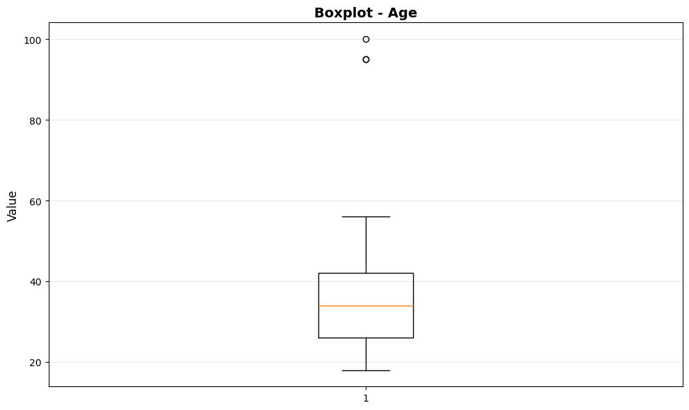

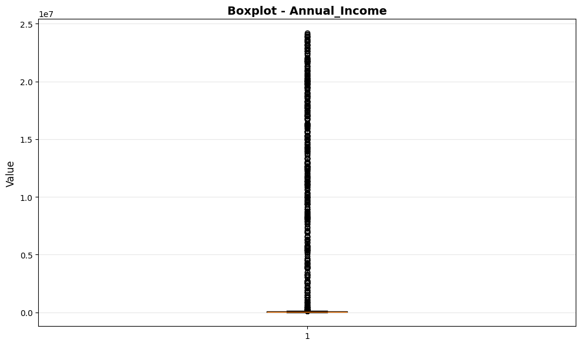

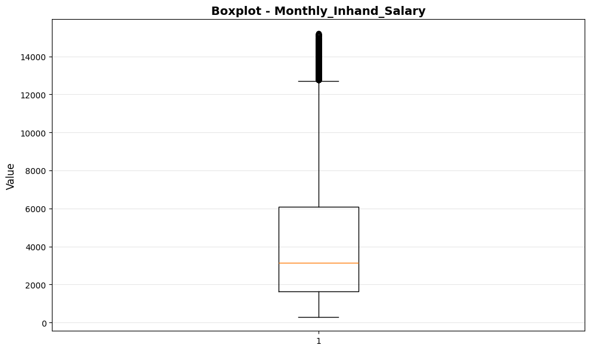

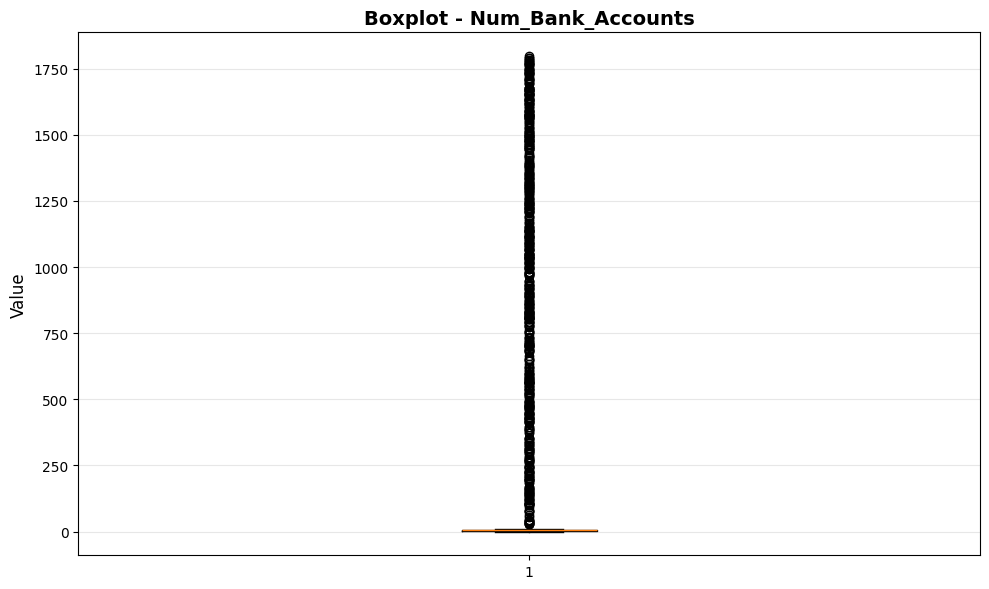

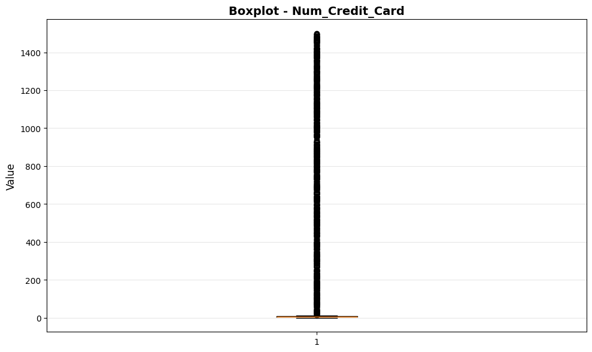

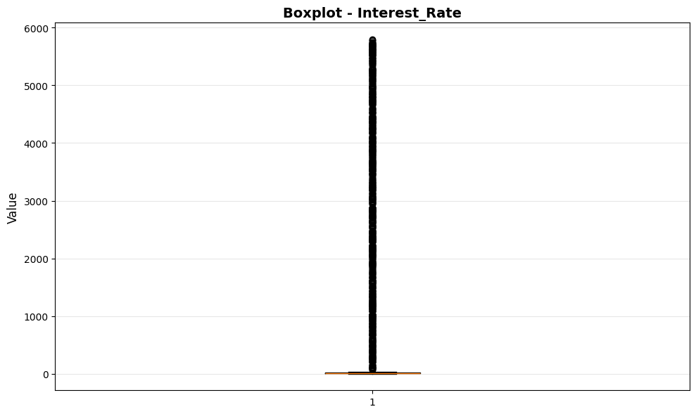

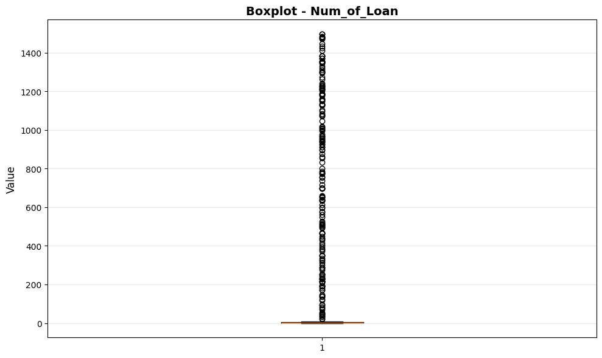

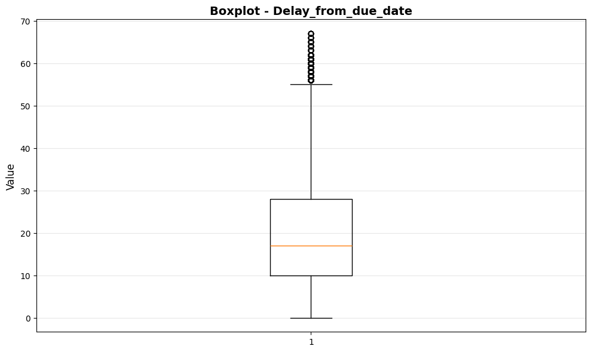

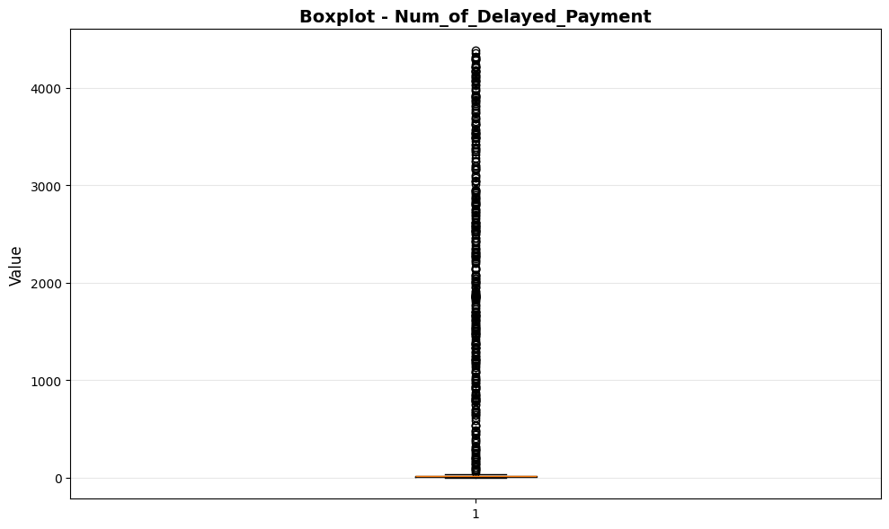

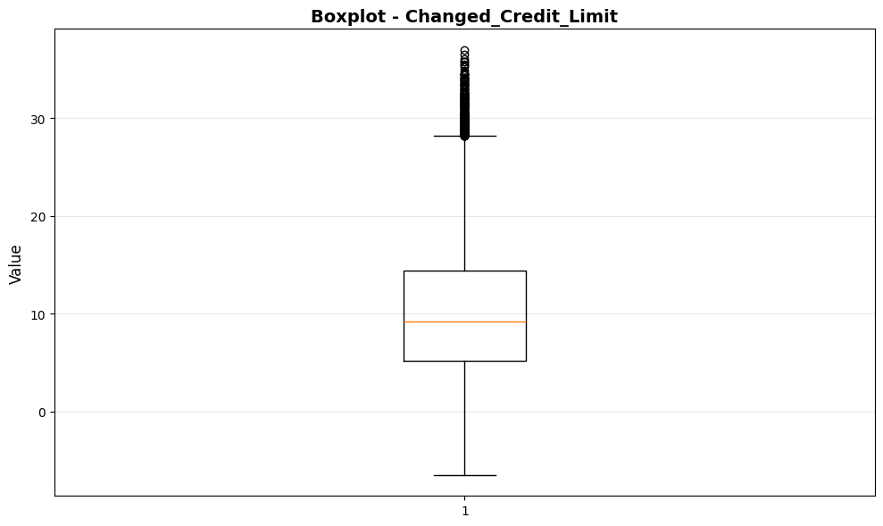

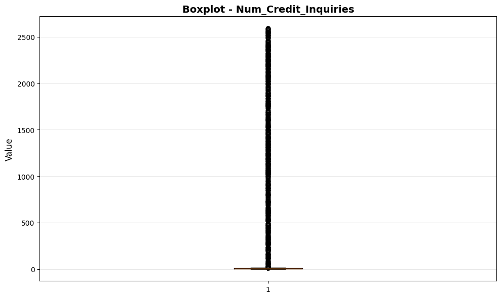

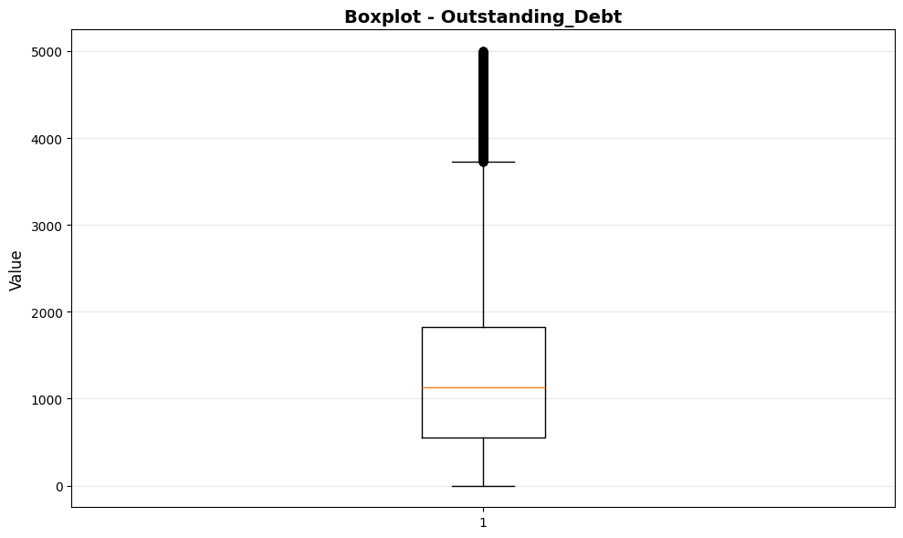

[13 more figures not shown]

```python
for col in num_col:
    fig, ax = plt.subplots(figsize=(10, 6))

    # Boxplot
    ax.boxplot(df_clean[col].dropna())

    # Formatting
    ax.set_title(f'Boxplot - {col}', fontsize=14, fontweight='bold')
    ax.set_ylabel('Value', fontsize=12)
    ax.grid(True, alpha=0.3, axis='y')

    plt.tight_layout()
    plt.show()
```

```python
for col in num_col:
    Q1 = df_clean[col].quantile(0.25)
    Q3 = df_clean[col].quantile(0.75)
    IQR = Q3 - Q1

    lower_bound = Q1 - 1.5 * IQR
    upper_bound = Q3 + 1.5 * IQR

    outliers = df_clean[(df_clean[col] < lower_bound) | (df_clean[col] > upper_bound)]
    outliers_count = len(outliers)
    outliers_pct = (outliers_count / len(df_clean)) * 100

    before_min = df_clean[col].min()
    before_max = df_clean[col].max()

    # Capping
    df_clean[col] = df_clean[col].clip(upper=upper_bound)

    after_min = df_clean[col].min()
    after_max = df_clean[col].max()

    # Print summary
    print(f"\n{col}:")
    print(f" Q1: {Q1:.2f} | Q3: {Q3:.2f} | IQR: {IQR:.2f}")
    print(f" Bounds: {lower_bound:.2f}, {upper_bound:.2f}")
    print(f" Outliers: {outliers_count} ({outliers_pct:.2f}%)")
    print(f" Before: [{before_min:.2f}, {before_max:.2f}]")
    print(f" After:  [{after_min:.2f}, {after_max:.2f}]")
```

```
Age:
 Q1: 26.00 | Q3: 42.00 | IQR: 16.00
 Bounds: 2.00, 66.00
 Outliers: 3 (0.01%)
 Before: [18.00, 100.00]
 After:  [18.00, 66.00]

Annual_Income:
 Q1: 19742.24 | Q3: 73928.46 | IQR: 54186.22
 Bounds: -61537.09, 155207.79
 Outliers: 1285 (2.81%)
 Before: [7006.03, 24198062.00]
 After:  [7006.03, 155207.79]

Monthly_Inhand_Salary:
 Q1: 1651.25 | Q3: 6078.74 | IQR: 4427.50
 Bounds: -4990.00, 12719.99
 Outliers: 733 (1.60%)
 Before: [303.65, 15204.63]
 After:  [303.65, 12719.99]

Num_Bank_Accounts:
 Q1: 3.00 | Q3: 7.00 | IQR: 4.00
 Bounds: -3.00, 13.00
 Outliers: 587 (1.28%)
 Before: [0.00, 1798.00]
 After:  [0.00, 13.00]

Num_Credit_Card:
 Q1: 4.00 | Q3: 7.00 | IQR: 3.00
 Bounds: -0.50, 11.50
 Outliers: 1084 (2.37%)
 Before: [0.00, 1499.00]
 After:  [0.00, 11.50]

Interest_Rate:
 Q1: 7.00 | Q3: 20.00 | IQR: 13.00
 Bounds: -12.50, 39.50
 Outliers: 967 (2.11%)
 Before: [1.00, 5797.00]
```

[output cut: 119 more lines]

```
 After:  [0.00, 2.50]

home_equity_loan_freq:
 Q1: 0.00 | Q3: 1.00 | IQR: 1.00
 Bounds: -1.50, 2.50
 Outliers: 426 (0.93%)
 Before: [0.00, 5.00]
 After:  [0.00, 2.50]

debt_consolidation_loan_freq:
 Q1: 0.00 | Q3: 1.00 | IQR: 1.00
 Bounds: -1.50, 2.50
 Outliers: 428 (0.93%)
 Before: [0.00, 5.00]
 After:  [0.00, 2.50]
```

I chose this method because its objective, consistent, and standard. I kept valid negative values like in Changed_Credit_Limit. This approach preserves all data while making it more realistic for accurate modeling without extreme values influencing the results

# B. Modeling

## Splitting data

```python
x = df_clean.drop(columns=['Credit_Score'])
y = df_clean['Credit_Score']
```

```python
x_train, x_test, y_train, y_test = train_test_split(x, y, test_size=0.2, random_state=42, stratify=y)
```

## Imbalance Check

```python
print("Distribusi kelas (count):")
print(y.value_counts())

print("\nDistribusi kelas (persentase):")
print(y.value_counts(normalize=True) * 100)
```

```
Distribusi kelas (count):
Credit_Score
1    24414
0    12835
2     8544
Name: count, dtype: int64

Distribusi kelas (persentase):
Credit_Score
1    53.313825
0    28.028301
2    18.657873
Name: proportion, dtype: float64
```

```python
print("Train:")
print(y_train.value_counts(normalize=True) * 100)

print("\nTest:")
print(y_test.value_counts(normalize=True) * 100)
```

```
Train:
Credit_Score
1    53.313861
0    28.028607
2    18.657531
Name: proportion, dtype: float64

Test:
Credit_Score
1    53.313681
0    28.027077
2    18.659242
Name: proportion, dtype: float64
```

There is imbalance where the standard value (class 1) has the most population and class 2 which is good is the minority class

## Pipelines

```python
cat_col = df_clean.select_dtypes(include='object')
num_col = df_clean.select_dtypes(include='number').drop(columns=['Credit_Score'])
```

```python
num_cols = num_col.columns
num_cols
```

```
Index(['Age', 'Annual_Income', 'Monthly_Inhand_Salary', 'Num_Bank_Accounts',
       'Num_Credit_Card', 'Interest_Rate', 'Num_of_Loan',
       'Delay_from_due_date', 'Num_of_Delayed_Payment', 'Changed_Credit_Limit',
       'Num_Credit_Inquiries', 'Outstanding_Debt', 'Credit_Utilization_Ratio',
       'Credit_History_Age', 'Total_EMI_per_month', 'Amount_invested_monthly',
       'Monthly_Balance', 'personal_loan_freq', 'credit-builder_loan_freq',
       'payday_loan_freq', 'student_loan_freq', 'mortgage_loan_freq',
       'auto_loan_freq', 'home_equity_loan_freq',
       'debt_consolidation_loan_freq'],
      dtype='object')
```

```python
for i in cat_col.columns:
    print(cat_col[i].value_counts())
    print("\n"*1)
```

```
Month
June        5748
January     5747
July        5746
August      5745
March       5740
May         5703
April       5694
February    5670
Name: count, dtype: int64


Occupation
Lawyer           3049
Engineer         2947
Developer        2919
Media_Manager    2892
Accountant       2870
Architect        2848
Entrepreneur     2843
Mechanic         2829
Teacher          2828
Scientist        2816
Journalist       2808
Doctor           2786
Musician         2732
Writer           2727
Manager          2717
Name: count, dtype: int64


Credit_Mix
Standard    16476
Good        11931
Bad          8130
Name: count, dtype: int64


Payment_of_Min_Amount
Yes    22873
No     17445
Name: count, dtype: int64


Payment_Behaviour
Low_spent_Small_value_payments      11530
High_spent_Medium_value_payments     8101
Low_spent_Medium_value_payments      6351
High_spent_Large_value_payments      6306
High_spent_Small_value_payments      5143
Low_spent_Large_value_payments       4839
Name: count, dtype: int64
```

```python
# Ordinal
payment_behavior_order = [
    'Low_spent_Small_value_payments',
    'Low_spent_Medium_value_payments',
    'Low_spent_Large_value_payments',
    'High_spent_Small_value_payments',
    'High_spent_Medium_value_payments',
    'High_spent_Large_value_payments'
]

numeric_imputer = Pipeline(steps=[
    ('imputer', SimpleImputer(strategy='median'))
])

ordinal_payment_behavior = Pipeline(steps=[
    ('imputer', SimpleImputer(strategy='most_frequent')),
    ('Ordinal_Payment', OrdinalEncoder(categories=[payment_behavior_order]))
])

ordinal_Credit_Mix = Pipeline(steps=[
    ('imputer', SimpleImputer(strategy='most_frequent')),
    ('Ordinal_Credit', OrdinalEncoder(categories=[['Bad', 'Standard', 'Good']]))
])

ordinal_Payment_Min_Amount = Pipeline(steps=[
    ('imputer', SimpleImputer(strategy='most_frequent')),
    ('Ordinal_Credit', OrdinalEncoder(categories=[['No', 'Yes']]))
])

# OHE
OHE = Pipeline(steps=[
    ('imputer', SimpleImputer(strategy='most_frequent')),
    ('OHE', OneHotEncoder(drop='first', handle_unknown='ignore'))
])
```

```python
# # Combine
# preprocessor = ColumnTransformer(
#     transformers=[
#         ('num_imputer', numeric_imputer, ['Monthly_Inhand_Salary', 'Num_of_Delayed_Payment',
#                                           'Changed_Credit_Limit', 'Num_Credit_Inquiries',
#                                           'Credit_History_Age',
#                                           'Amount_invested_monthly',
#                                           'Monthly_Balance']),
#         ('ordinal_PB', ordinal_payment_behavior, ['Payment_Behaviour']),
#         ('ordinal_CM', ordinal_Credit_Mix, ['Credit_Mix']),
#         ('ordinal_PMA', ordinal_Payment_Min_Amount, ['Payment_of_Min_Amount']),
#         ('ohe', OHE, ['Month', 'Occupation'])
#     ], remainder='passthrough'
# )
```

```python
# Combine
preprocessor = ColumnTransformer(
    transformers=[
        ('num_imputer', numeric_imputer, num_cols),
        ('ordinal_PB', ordinal_payment_behavior, ['Payment_Behaviour']),
        ('ordinal_CM', ordinal_Credit_Mix, ['Credit_Mix']),
        ('ordinal_PMA', ordinal_Payment_Min_Amount, ['Payment_of_Min_Amount']),
        ('ohe', OHE, ['Month', 'Occupation'])
    ], remainder='passthrough'
)
```

### Random Forest

#### Baseline Model

```python
pipeline_rf = Pipeline(steps=[
    ('preprocessor', preprocessor),
    ('model', RandomForestClassifier(
        random_state=42,
        n_jobs=-2))
])

param_grid_rf = {
    'model__n_estimators': [50, 100, 150, 200],
    'model__max_depth': [10, 15, 20, None],
    'model__min_samples_split': [2, 5, 10, 15],
    'model__min_samples_leaf': [1, 2, 4, 8],
}

rs_rf = RandomizedSearchCV(
    estimator=pipeline_rf,
    param_distributions=param_grid_rf,
    n_iter=30,
    cv=StratifiedKFold(5, shuffle=True, random_state=42),
    scoring='f1_weighted',
    verbose=1,
    random_state=42,
    n_jobs=-3
)
```

```python
rs_rf.fit(x_train, y_train)
```

```
Fitting 5 folds for each of 30 candidates, totalling 150 fits
```

```
RandomizedSearchCV(cv=StratifiedKFold(n_splits=5, random_state=42, shuffle=True),
                   estimator=Pipeline(steps=[('preprocessor',
                                              ColumnTransformer(remainder='passthrough',
                                                                transformers=[('num_imputer',
                                                                               Pipeline(steps=[('imputer',
                                                                                                SimpleImputer(strategy='median'))]),
                                                                               Index(['Age', 'Annual_Income', 'Monthly_Inhand_Salary', 'Num_Bank_Accounts',
       'Num_Credit_Card', 'Int...
                                                                                                              handle_unknown='ignore'))]),
                                                                               ['Month',
                                                                                'Occupation'])])),
                                             ('model',
                                              RandomForestClassifier(n_jobs=-2,
                                                                     random_state=42))]),
                   n_iter=30, n_jobs=-3,
                   param_distributions={'model__max_depth': [10, 15, 20, None],
                                        'model__min_samples_leaf': [1, 2, 4, 8],
                                        'model__min_samples_split': [2, 5, 10,
                                                                     15],
                                        'model__n_estimators': [50, 100, 150,
                                                                200]},
                   random_state=42, scoring='f1_weighted', verbose=1)
```

```python
print(f"Baseline")
print(f"Best Score   :{rs_rf.best_score_:.4f}")
print(f"Best Params :{rs_rf.best_params_}")
```

```
Baseline
Best Score   :0.7504
Best Params :{'model__n_estimators': 200, 'model__min_samples_split': 5, 'model__min_samples_leaf': 1, 'model__max_depth': None}
```

#### Class Weight

```python
pipeline_cw = Pipeline([
    ('preprocessor', preprocessor),
    ('model', RandomForestClassifier(
        class_weight='balanced',
        random_state=42,
        n_jobs=-2
    ))
])

rs_cw = RandomizedSearchCV(
    pipeline_cw,
    param_grid_rf,
    n_iter=30,
    cv=StratifiedKFold(5, shuffle=True, random_state=42),
    scoring='f1_weighted',
    random_state=42,
    n_jobs=-3,
    verbose=1
)
```

```python
rs_cw.fit(x_train, y_train)
```

```
Fitting 5 folds for each of 30 candidates, totalling 150 fits
```

```
RandomizedSearchCV(cv=StratifiedKFold(n_splits=5, random_state=42, shuffle=True),
                   estimator=Pipeline(steps=[('preprocessor',
                                              ColumnTransformer(remainder='passthrough',
                                                                transformers=[('num_imputer',
                                                                               Pipeline(steps=[('imputer',
                                                                                                SimpleImputer(strategy='median'))]),
                                                                               Index(['Age', 'Annual_Income', 'Monthly_Inhand_Salary', 'Num_Bank_Accounts',
       'Num_Credit_Card', 'Int...
                                                                               ['Month',
                                                                                'Occupation'])])),
                                             ('model',
                                              RandomForestClassifier(class_weight='balanced',
                                                                     n_jobs=-2,
                                                                     random_state=42))]),
                   n_iter=30, n_jobs=-3,
                   param_distributions={'model__max_depth': [10, 15, 20, None],
                                        'model__min_samples_leaf': [1, 2, 4, 8],
                                        'model__min_samples_split': [2, 5, 10,
                                                                     15],
                                        'model__n_estimators': [50, 100, 150,
                                                                200]},
                   random_state=42, scoring='f1_weighted', verbose=1)
```

```python
print(f"Class Weight")
print(f"Best Score  :{rs_cw.best_score_:.4f}")
print(f"Best Params :{rs_cw.best_params_}")
```

```
Class Weight
Best Score  :0.7523
Best Params :{'model__n_estimators': 200, 'model__min_samples_split': 5, 'model__min_samples_leaf': 1, 'model__max_depth': None}
```

#### SMOTE

```python
pipeline_smote = ImbPipeline([
    ('preprocessor', preprocessor),
    ('smote', SMOTE(random_state=42, k_neighbors=5)),
    ('model', RandomForestClassifier(random_state=42, n_jobs=-2))
])

rs_smote = RandomizedSearchCV(
    pipeline_smote,
    param_grid_rf,
    n_iter=30,
    cv=5,
    scoring='f1_weighted',
    random_state=42,
    n_jobs=-3,
    verbose=1
)
```

```python
rs_smote.fit(x_train, y_train)
```

```
Fitting 5 folds for each of 30 candidates, totalling 150 fits
```

```
RandomizedSearchCV(cv=5,
                   estimator=Pipeline(steps=[('preprocessor',
                                              ColumnTransformer(remainder='passthrough',
                                                                transformers=[('num_imputer',
                                                                               Pipeline(steps=[('imputer',
                                                                                                SimpleImputer(strategy='median'))]),
                                                                               Index(['Age', 'Annual_Income', 'Monthly_Inhand_Salary', 'Num_Bank_Accounts',
       'Num_Credit_Card', 'Interest_Rate', 'Num_of_Loan',
       'Delay_from_due_date', 'Num_of...
                                                                                'Occupation'])])),
                                             ('smote', SMOTE(random_state=42)),
                                             ('model',
                                              RandomForestClassifier(n_jobs=-2,
                                                                     random_state=42))]),
                   n_iter=30, n_jobs=-3,
                   param_distributions={'model__max_depth': [10, 15, 20, None],
                                        'model__min_samples_leaf': [1, 2, 4, 8],
                                        'model__min_samples_split': [2, 5, 10,
                                                                     15],
                                        'model__n_estimators': [50, 100, 150,
                                                                200]},
                   random_state=42, scoring='f1_weighted', verbose=1)
```

```python
print(f"SMOTE")
print(f"Best Score  :{rs_smote.best_score_:.4f}")
print(f"Best Params :{rs_smote.best_params_}")
```

```
SMOTE
Best Score  :0.7384
Best Params :{'model__n_estimators': 200, 'model__min_samples_split': 5, 'model__min_samples_leaf': 1, 'model__max_depth': None}
```

#### Evaluation

```python
models = {
    'Baseline': rs_rf.best_estimator_,
    'Class Weight': rs_cw.best_estimator_,
    'SMOTE': rs_smote.best_estimator_
}

evaluation_results = {}

for model_name, model in models.items():
    print(f"{model_name.upper()}")

    y_pred = model.predict(x_test)

    # Metrics
    accuracy = accuracy_score(y_test, y_pred)
    precision = precision_score(y_test, y_pred, average='weighted', zero_division=0)
    recall = recall_score(y_test, y_pred, average='weighted', zero_division=0)
    f1 = f1_score(y_test, y_pred, average='weighted', zero_division=0)

    evaluation_results[model_name] = {
        'Accuracy': accuracy,
        'Precision': precision,
        'Recall': recall,
        'F1-Score': f1,
        'Predictions': y_pred
    }

    print(f"Accuracy:  {accuracy:.4f}")
    print(f"Precision: {precision:.4f}")
    print(f"Recall:    {recall:.4f}")
    print(f"F1-Score:  {f1:.4f}")

    # Per-class metrics
    print("\nPer-class Metrics:")

    prec, recall_pc, f1_pc, support = precision_recall_fscore_support(
        y_test, y_pred, average=None, zero_division=0
    )

    for i in range(len(f1_pc)):
        print(f"  Class {i}: Precision={prec[i]:.4f}, Recall={recall_pc[i]:.4f}, F1={f1_pc[i]:.4f}")

    # Confusion Matrix
    print("\nConfusion Matrix:")
    cm = confusion_matrix(y_test, y_pred)
    print(cm)

    # Classification Report
    print("\nClassification Report:")
    print(classification_report(y_test, y_pred, zero_division=0))
```

```
BASELINE
Accuracy:  0.7595
Precision: 0.7600
Recall:    0.7595
F1-Score:  0.7593

Per-class Metrics:
  Class 0: Precision=0.7862, Recall=0.7261, F1=0.7550
  Class 1: Precision=0.7771, Recall=0.8034, F1=0.7901
  Class 2: Precision=0.6718, Recall=0.6840, F1=0.6779

Confusion Matrix:
[[1864  599  104]
 [ 493 3923  467]
 [  14  526 1169]]

Classification Report:
              precision    recall  f1-score   support

           0       0.79      0.73      0.75      2567
           1       0.78      0.80      0.79      4883
           2       0.67      0.68      0.68      1709

    accuracy                           0.76      9159
   macro avg       0.75      0.74      0.74      9159
weighted avg       0.76      0.76      0.76      9159

CLASS WEIGHT
Accuracy:  0.7586
Precision: 0.7616
Recall:    0.7586
F1-Score:  0.7595

Per-class Metrics:
  Class 0: Precision=0.7740, Recall=0.7417, F1=0.7575
  Class 1: Precision=0.7939, Recall=0.7780, F1=0.7859
  Class 2: Precision=0.6505, Recall=0.7285, F1=0.6873

Confusion Matrix:
[[1904  538  125]
```

[output cut: 25 more lines]

```
Confusion Matrix:
[[1892  484  191]
 [ 578 3613  692]
 [  20  420 1269]]

Classification Report:
              precision    recall  f1-score   support

           0       0.76      0.74      0.75      2567
           1       0.80      0.74      0.77      4883
           2       0.59      0.74      0.66      1709

    accuracy                           0.74      9159
   macro avg       0.72      0.74      0.72      9159
weighted avg       0.75      0.74      0.74      9159
```

Based on the eval metrics i will use the random forest class weight with f1-macro 0.74 which is stabil and increase in recall for class 2( minority from 0.68 to 0.73) without trading off too much precision significantly

### XGBoost

#### Baseline

```python
pipeline_xgb = Pipeline([
    ('preprocessor', preprocessor),
    ('model', XGBClassifier(
        num_class = 3,
        random_state=42,
        n_jobs=-1,
        eval_metric='mlogloss',
        verbosity=0
    ))
])

param_grid_xgb = {
    'model__n_estimators': [100, 200, 300],
    'model__max_depth': [4, 6, 8],
    'model__learning_rate': [0.01, 0.05, 0.1],
    'model__subsample': [0.7, 0.8, 0.9],
    'model__colsample_bytree': [0.7, 0.8, 0.9],
}

rs_xgb = RandomizedSearchCV(
    estimator=pipeline_xgb,
    param_distributions=param_grid_xgb,
    n_iter=30,
    cv=StratifiedKFold(5, shuffle=True, random_state=42),
    scoring='f1_weighted',
    verbose=1,
    random_state=42,
    n_jobs=-3
)
```

```python
rs_xgb.fit(x_train, y_train)
```

```
Fitting 5 folds for each of 30 candidates, totalling 150 fits
```

```
RandomizedSearchCV(cv=StratifiedKFold(n_splits=5, random_state=42, shuffle=True),
                   estimator=Pipeline(steps=[('preprocessor',
                                              ColumnTransformer(remainder='passthrough',
                                                                transformers=[('num_imputer',
                                                                               Pipeline(steps=[('imputer',
                                                                                                SimpleImputer(strategy='median'))]),
                                                                               Index(['Age', 'Annual_Income', 'Monthly_Inhand_Salary', 'Num_Bank_Accounts',
       'Num_Credit_Card', 'Int...
                                                            monotone_constraints=None,
                                                            multi_strategy=None,
                                                            n_estimators=None,
                                                            n_jobs=-1,
                                                            num_class=3, ...))]),
                   n_iter=30, n_jobs=-3,
                   param_distributions={'model__colsample_bytree': [0.7, 0.8,
                                                                    0.9],
                                        'model__learning_rate': [0.01, 0.05,
                                                                 0.1],
                                        'model__max_depth': [4, 6, 8],
                                        'model__n_estimators': [100, 200, 300],
                                        'model__subsample': [0.7, 0.8, 0.9]},
                   random_state=42, scoring='f1_weighted', verbose=1)
```

```python
print(f"Class Weight")
print(f"Best Score: {rs_xgb.best_score_:.4f}\n")
```

```
Class Weight
Best Score: 0.7537
```